# 09 - Multiple linear regression

Francisco E. Fonturbel

07/November/2025

## Multiple linear regression

Now that we know how to fit linear models, let’s try something bolder. Why limiting us to a single predictor variable? In biological sciences, many phenomena depend on two or more variables than can be used to explain our response variable. Thus, the multivariate extension or linear regression is called **Multiple linear regression**. In this case, our linear model looks like this:

*y = a + b1x1 + b2x2 + b3x3 + … + bnxn*

Being y the response variable, a and b’s the coefficients, and x’s the predictor variables in the model.

So, we will use the same `lm()` function but incorporating more than one predictor variable in the formula.

Let’s use the `mtcars` dataset (included in R) to make an example of this

```r
library(confintr)
library(ggplot2)
library(dplyr)
library(gridExtra)

data<-mtcars[,c("mpg","disp","hp","wt")]
attach(data)
head(data)
```

```
##                    mpg disp  hp    wt
## Mazda RX4         21.0  160 110 2.620
## Mazda RX4 Wag     21.0  160 110 2.875
## Datsun 710        22.8  108  93 2.320
## Hornet 4 Drive    21.4  258 110 3.215
## Hornet Sportabout 18.7  360 175 3.440
## Valiant           18.1  225 105 3.460
```

So, we have information on several car brands and models, obtained from their technical specifications. In this case, we want to know which factors determine car’s efficiency in fuel use (represented by the variable mpg = miles per gallon) regarding three factors: cylinder displacement (disp), power (hp), and car’s weight (wt). Let’s fit a linear model for this:

```r
mod1<-lm(mpg~disp+hp+wt, data = data)
summary(mod1)
```

```
##
## Call:
## lm(formula = mpg ~ disp + hp + wt, data = data)
##
## Residuals:
##    Min     1Q Median     3Q    Max
## -3.891 -1.640 -0.172  1.061  5.861
##
## Coefficients:
##              Estimate Std. Error t value Pr(>|t|)
## (Intercept) 37.105505   2.110815  17.579  < 2e-16 ***
## disp        -0.000937   0.010350  -0.091  0.92851
## hp          -0.031157   0.011436  -2.724  0.01097 *
## wt          -3.800891   1.066191  -3.565  0.00133 **
## ---
## Signif. codes:  0 '***' 0.001 '**' 0.01 '*' 0.05 '.' 0.1 ' ' 1
##
## Residual standard error: 2.639 on 28 degrees of freedom
## Multiple R-squared:  0.8268, Adjusted R-squared:  0.8083
## F-statistic: 44.57 on 3 and 28 DF,  p-value: 8.65e-11
```

As we can see here, cylinder displacement has no significant effect on gas consumption, but power and weight do have a significant effect, with negative relationships (i.e., the more powerful and heavy vehicle, the less gas efficiency).

So, now that we now which variables are important, we may fit a second model examining the interaction between these variables:

```r
mod2<-lm(mpg~hp*wt, data = data)
summary(mod2)
```

```
##
## Call:
## lm(formula = mpg ~ hp * wt, data = data)
##
## Residuals:
##     Min      1Q  Median      3Q     Max
## -3.0632 -1.6491 -0.7362  1.4211  4.5513
##
## Coefficients:
##             Estimate Std. Error t value Pr(>|t|)
## (Intercept) 49.80842    3.60516  13.816 5.01e-14 ***
## hp          -0.12010    0.02470  -4.863 4.04e-05 ***
## wt          -8.21662    1.26971  -6.471 5.20e-07 ***
## hp:wt        0.02785    0.00742   3.753 0.000811 ***
## ---
## Signif. codes:  0 '***' 0.001 '**' 0.01 '*' 0.05 '.' 0.1 ' ' 1
##
## Residual standard error: 2.153 on 28 degrees of freedom
## Multiple R-squared:  0.8848, Adjusted R-squared:  0.8724
## F-statistic: 71.66 on 3 and 28 DF,  p-value: 2.981e-13
```

### How good is our model?

As in univariate linear regression, we may examine R-squared and residual distribution to determine how well our model describes the data.

**R-squared**

For the first model:

```r
summary(mod1)$r.squared
```

```
## [1] 0.8268361
```

For the second model:

```r
summary(mod2)$r.squared
```

```
## [1] 0.8847637
```

(not bad!)

**Residuals**

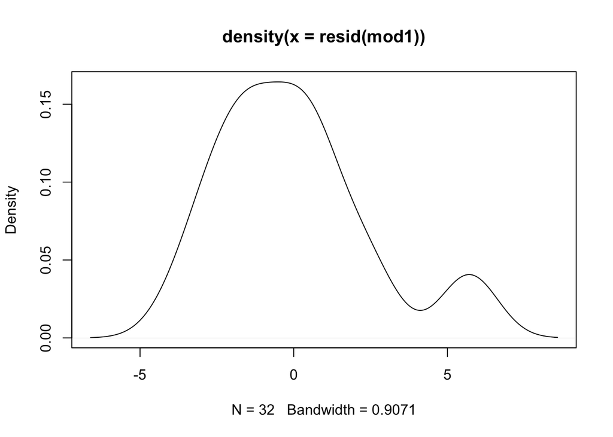

```r
plot(density(resid(mod1))) #A density plot
```

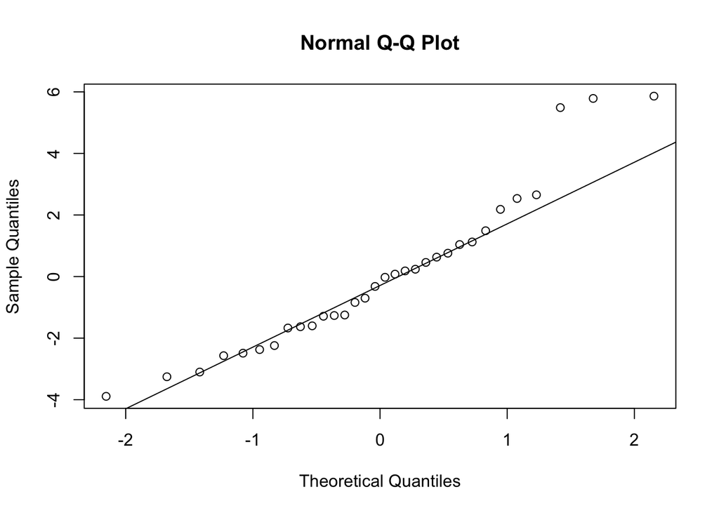

```r
qqnorm(resid(mod1)) # A quantile normal plot - good for checking normality
qqline(resid(mod1))
```

Uhmmm…. are those residuals normal?

```r
shapiro.test(resid(mod1))
```

```
##
##  Shapiro-Wilk normality test
##
## data:  resid(mod1)
## W = 0.92734, p-value = 0.03305
```

No, they are not. Let’s take a look to the second model instead:

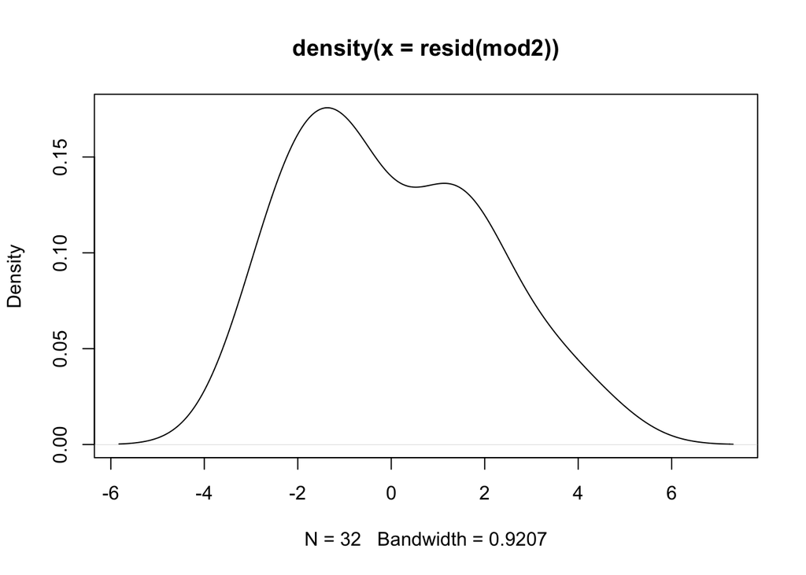

```r
plot(density(resid(mod2))) #A density plot
```

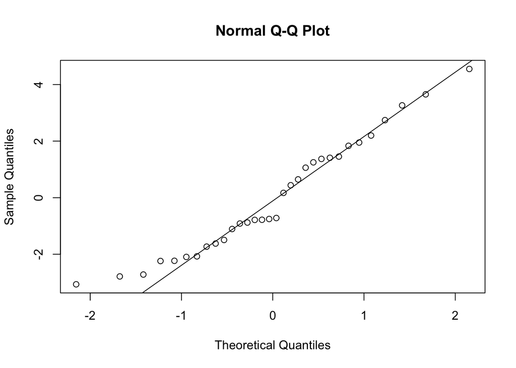

```r
qqnorm(resid(mod2)) # A quantile normal plot - good for checking normality
qqline(resid(mod2))
```

Better, but are those residuals normal?

```r
shapiro.test(resid(mod2))
```

```
##
##  Shapiro-Wilk normality test
##
## data:  resid(mod2)
## W = 0.95447, p-value = 0.1928
```

Great, now they are normal.

Last but not least, let’s make some nice plots!

[figure not shown]

```r
# Assuming mod2 is already fitted: mod2 <- lm(mpg ~ hp * wt, data = mtcars)

# 1. 3D-style interaction plot showing the fitted surface
# Create a grid of hp and wt values for prediction
hp_seq <- seq(min(data$hp), max(data$hp), length.out = 30)
wt_seq <- seq(min(data$wt), max(data$wt), length.out = 30)
pred_grid <- expand.grid(hp = hp_seq, wt = wt_seq)
pred_grid$mpg_pred <- predict(mod2, newdata = pred_grid)

# Plot 1: Contour plot showing the interaction surface
p1 <- ggplot() +
  geom_contour_filled(data = pred_grid, aes(x = hp, y = wt, z = mpg_pred), alpha = 0.7) +
  geom_point(data = data, aes(x = hp, y = wt, size = mpg), shape = 21,
             fill = "white", color = "black", stroke = 1.5) +
  scale_fill_viridis_d(name = "Predicted\nMPG") +
  labs(title = "MPG as a Function of Horsepower and Weight",
       subtitle = "Interaction model: mpg ~ hp * wt",
       x = "Horsepower (hp)",
       y = "Weight (1000 lbs)",
       size = "Observed\nMPG") +
  theme_minimal() +
  theme(plot.title = element_text(face = "bold", size = 14),
        legend.position = "right")

# Plot 2: Interaction plot - effect of hp at different wt levels
wt_levels <- quantile(data$wt, probs = c(0.25, 0.5, 0.75))
pred_data_wt <- expand.grid(
  hp = seq(min(data$hp), max(data$hp), length.out = 100),
  wt = wt_levels
)
pred_data_wt$mpg_pred <- predict(mod2, newdata = pred_data_wt)
pred_data_wt$wt_category <- factor(pred_data_wt$wt,
                                    labels = c("Light (25th %ile)",
                                             "Medium (50th %ile)",
                                             "Heavy (75th %ile)"))

p2 <- ggplot(pred_data_wt, aes(x = hp, y = mpg_pred, color = wt_category,
                                linetype = wt_category)) +
  geom_line(size = 1.2) +
  geom_point(data = data, aes(x = hp, y = mpg),
             color = "black", alpha = 0.5, inherit.aes = FALSE) +
  scale_color_manual(values = c("#2E86AB", "#A23B72", "#F18F01")) +
  labs(title = "Effect of Horsepower on MPG at Different Weight Levels",
       subtitle = "Lines show predicted values from interaction model",
       x = "Horsepower (hp)",
       y = "Miles per Gallon (MPG)",
       color = "Vehicle Weight",
       linetype = "Vehicle Weight") +
  theme_minimal() +
  theme(plot.title = element_text(face = "bold", size = 12),
        legend.position = "bottom")

# Plot 3: Interaction plot - effect of wt at different hp levels
hp_levels <- quantile(data$hp, probs = c(0.25, 0.5, 0.75))
pred_data_hp <- expand.grid(
  wt = seq(min(data$wt), max(data$wt), length.out = 100),
  hp = hp_levels
)
pred_data_hp$mpg_pred <- predict(mod2, newdata = pred_data_hp)
pred_data_hp$hp_category <- factor(pred_data_hp$hp,
                                    labels = c("Low Power (25th %ile)",
                                             "Medium Power (50th %ile)",
                                             "High Power (75th %ile)"))

p3 <- ggplot(pred_data_hp, aes(x = wt, y = mpg_pred, color = hp_category,
                                linetype = hp_category)) +
  geom_line(size = 1.2) +
  geom_point(data = data, aes(x = wt, y = mpg),
             color = "black", alpha = 0.5, inherit.aes = FALSE) +
  scale_color_manual(values = c("#06A77D", "#D4A017", "#C73E1D")) +
  labs(title = "Effect of Weight on MPG at Different Horsepower Levels",
       subtitle = "Lines show predicted values from interaction model",
       x = "Weight (1000 lbs)",
       y = "Miles per Gallon (MPG)",
       color = "Engine Power",
       linetype = "Engine Power") +
  theme_minimal() +
  theme(plot.title = element_text(face = "bold", size = 12),
        legend.position = "bottom")



# Display all plots
print(p1)
```

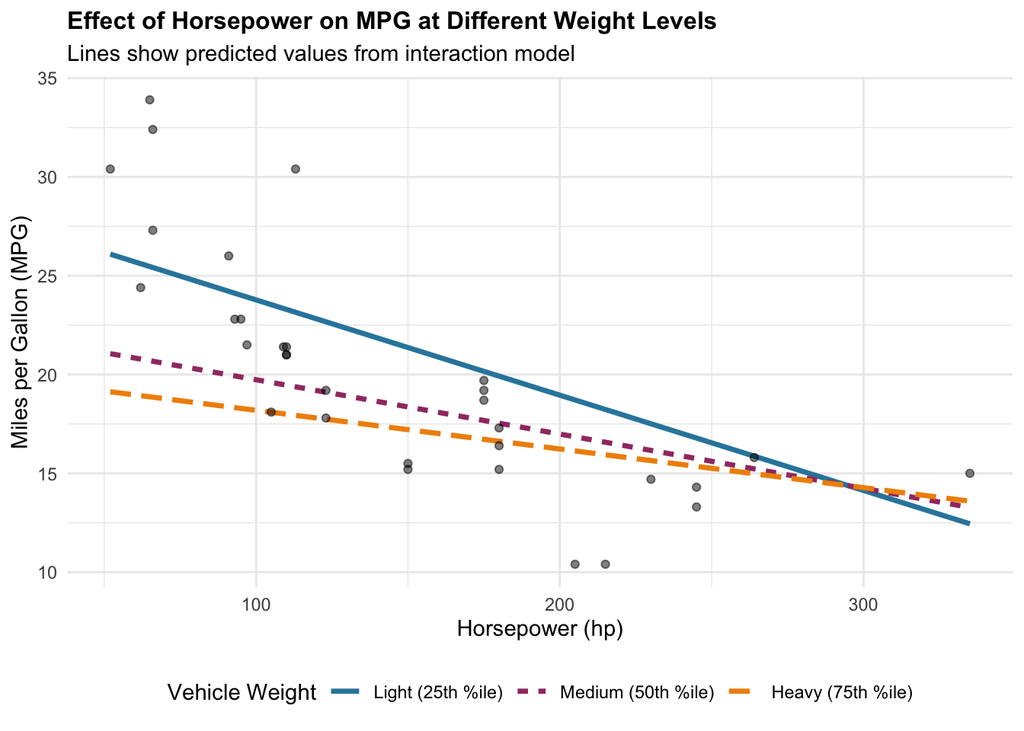

```r
print(p2)
```

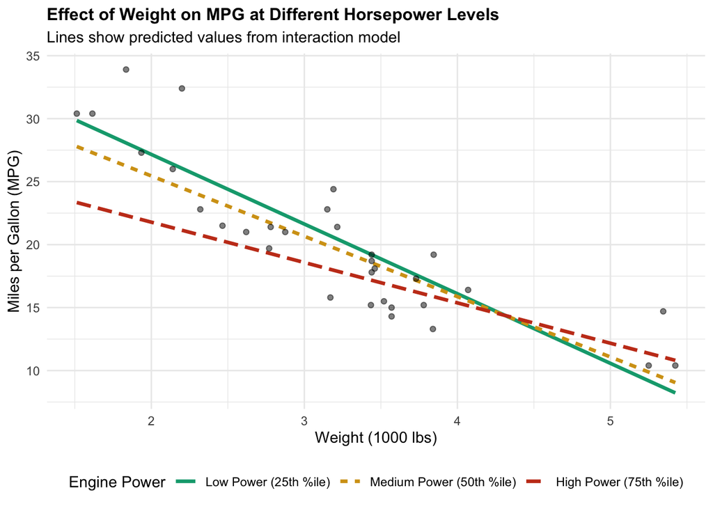

```r
print(p3)
```

## Final thoughts

Multiple linear regression works in the same way than linear regression with a single variable. We rely on the same assumptions but we have the flexibility to add several continuous variables to explain our response variable.

Licensing Creative Commons License

Licensed under a Creative Commons Attribution-ShareAlike 4.0 International License.  
2025 - Francisco E. Fontúrbel